# APAN5420_Assignment12_Zhifeng Wang

```python
target = 'loan_default'
from sklearn.model_selection import train_test_split
train, test = train_test_split(
     data, test_size=0.40, random_state=42)
```

```python
train.shape
```

```
(4800, 33)
```

```python
var = pd.DataFrame(train.dtypes)
var.head(10)
```

|  | 0 |
| --- | --- |
| Unnamed: 0.1 | int64 |
| Unnamed: 0 | int64 |
| id | int64 |
| loan_default | int64 |
| AP001 | int64 |
| AP002 | int64 |
| AP003 | int64 |
| AP004 | int64 |
| AP005 | object |
| AP007 | int64 |

```python
var = pd.DataFrame(train.dtypes).reset_index()
var.head()
```

|  | index | 0 |
| --- | --- | --- |
| 0 | Unnamed: 0.1 | int64 |
| 1 | Unnamed: 0 | int64 |
| 2 | id | int64 |
| 3 | loan_default | int64 |
| 4 | AP001 | int64 |

```python
var.columns = ['varname','dtype']
var.head(10)
```

|  | varname | dtype |
| --- | --- | --- |
| 0 | Unnamed: 0.1 | int64 |
| 1 | Unnamed: 0 | int64 |
| 2 | id | int64 |
| 3 | loan_default | int64 |
| 4 | AP001 | int64 |
| 5 | AP002 | int64 |
| 6 | AP003 | int64 |
| 7 | AP004 | int64 |
| 8 | AP005 | object |
| 9 | AP007 | int64 |

```python
var['source'] = var['varname'].str[:2]
var.head()
```

|  | varname | dtype | source |
| --- | --- | --- | --- |
| 0 | Unnamed: 0.1 | int64 | Un |
| 1 | Unnamed: 0 | int64 | Un |
| 2 | id | int64 | id |
| 3 | loan_default | int64 | lo |
| 4 | AP001 | int64 | AP |

```python
var['source'].value_counts()
```

```
source
AP    12
TD     9
CR     7
Un     2
id     1
lo     1
MB     1
Name: count, dtype: int64
```

```python
# "AP004" is a bad data field and should be removed.
MB_list = list(var[var['source']=='MB']['varname'])
AP_list = list(var[(var['source']=='AP') & (var['varname']!='AP004')]['varname'])
TD_list = list(var[var['source']=='TD']['varname'])
CR_list = list(var[var['source']=='CR']['varname'])
PA_list = list(var[var['source']=='PA']['varname'])
CD_list = list(var[var['source']=='CD']['varname'])
AP_list
```

```
['AP001',
 'AP002',
 'AP003',
 'AP005',
 'AP007',
 'AP008',
 'AP009',
 'AP006_android',
 'AP006_api',
 'AP006_h5',
 'AP006_ios']
```

```python
train['loan_default'].value_counts(dropna=False)
```

```
loan_default
0    3845
1     955
Name: count, dtype: int64
```

```python
train
```

|  | Unnamed: 0.1 | Unnamed: 0 | id | loan_default | AP001 | AP002 | AP003 | AP004 | AP005 | AP007 | ... | CR009 | CR015 | CR017 | CR018 | CR019 | MB007 | AP006_android | AP006_api | AP006_h5 | AP006_ios |
| --- | --- | --- | --- | --- | --- | --- | --- | --- | --- | --- | --- | --- | --- | --- | --- | --- | --- | --- | --- | --- | --- |
| 50052 | 50052 | 50053 | 50053 | 1 | 27 | 1 | 3 | 12 | 2017/4/5 17:30 | 5 | ... | 3200 | 3 | 2 | 2 | 4 | WEB | False | False | True | False |
| 56822 | 56822 | 56823 | 56823 | 0 | 36 | 1 | 3 | 12 | 2017/5/28 13:26 | 3 | ... | 4000 | 5 | 3 | 3 | 3 | WEB | False | False | True | False |
| 25904 | 25904 | 25905 | 25905 | 0 | 29 | 1 | 3 | 12 | 2017/4/5 14:50 | 4 | ... | 0 | 5 | 7 | 7 | 6 | Noinfo | False | False | True | False |
| 53165 | 53165 | 53166 | 53166 | 1 | 26 | 1 | 4 | 12 | 2017/4/5 12:15 | 2 | ... | 33500 | 5 | 8 | 8 | 11 | WEB | False | False | True | False |
| 33140 | 33140 | 33141 | 33141 | 0 | 27 | 1 | 3 | 12 | 2017/4/22 12:35 | 1 | ... | 10500 | 3 | 1 | 1 | 2 | WEB | False | False | True | False |
| ... | ... | ... | ... | ... | ... | ... | ... | ... | ... | ... | ... | ... | ... | ... | ... | ... | ... | ... | ... | ... | ... |
| 75646 | 75646 | 75647 | 75647 | 0 | 28 | 1 | 4 | 12 | 2017/5/15 10:15 | 5 | ... | 36623 | 6 | 7 | 5 | 4 | WEB | False | False | True | False |
| 62500 | 62500 | 62501 | 62501 | 0 | 32 | 2 | 1 | 12 | 2017/6/23 17:16 | 3 | ... | 16096 | 6 | 7 | 6 | 5 | WEB | False | False | True | False |
| 67861 | 67861 | 67862 | 67862 | 0 | 30 | 2 | 3 | 12 | 2017/7/3 14:14 | 5 | ... | 11380 | 4 | 3 | 3 | 3 | GIONEE | True | False | False | False |
| 68243 | 68243 | 68244 | 68244 | 0 | 35 | 2 | 1 | 6 | 2017/6/18 4:01 | 3 | ... | 11338 | 6 | 7 | 6 | 7 | WEB | False | False | True | False |
| 16980 | 16980 | 16981 | 16981 | 0 | 35 | 1 | 1 | 12 | 2017/5/18 10:28 | 2 | ... | 0 | 6 | 4 | 5 | 4 | WEB | False | False | True | False |

4800 rows × 33 columns

```python
pip install h2o
```

## Section 2 RF

```python
def VarImp(model_name, m_name):
    from sklearn.metrics import roc_curve, auc
    from sklearn.metrics import average_precision_score
    from sklearn.metrics import precision_recall_curve
    import matplotlib.pyplot as plt
    import pandas as pd

    # Get variable importance data
    variables = model_name._model_json['output']['variable_importances']['variable']
    scaled_importance = model_name._model_json['output']['variable_importances']['scaled_importance']
    percentage = model_name._model_json['output']['variable_importances']['percentage']

    # Create DataFrame
    var_imp_df = pd.DataFrame({
        'variable': variables,
        'scaled_importance': scaled_importance,
        'percentage': percentage
    }).sort_values('scaled_importance', ascending=False)

    # Plot the variable importance
    plt.rcdefaults()
    y_pos = np.arange(len(variables))
    fig, ax = plt.subplots(figsize=(6, len(variables)/2))
    ax.barh(y_pos, scaled_importance, align='center', color='green')
    ax.set_yticks(y_pos)
    ax.set_yticklabels(variables)
    ax.invert_yaxis()
    ax.set_xlabel('Scaled Importance')
    ax.set_title(m_name + ' Variable Importance')
    plt.show()

    return var_imp_df
```

```python
import h2o
h2o.init()
```

```
Checking whether there is an H2O instance running at http://localhost:54321. connected.
```

| H2O_cluster_uptime: | 7 days 21 hours 12 mins |
| --- | --- |
| H2O_cluster_timezone: | America/New_York |
| H2O_data_parsing_timezone: | UTC |
| H2O_cluster_version: | 3.46.0.6 |
| H2O_cluster_version_age: | 1 month and 9 days |
| H2O_cluster_name: | H2O_from_python_zhifengwang_epy66v |
| H2O_cluster_total_nodes: | 1 |
| H2O_cluster_free_memory: | 2.859 Gb |
| H2O_cluster_total_cores: | 8 |
| H2O_cluster_allowed_cores: | 8 |
| H2O_cluster_status: | locked, healthy |
| H2O_connection_url: | http://localhost:54321 |
| H2O_connection_proxy: | {"http": null, "https": null} |
| H2O_internal_security: | False |
| Python_version: | 3.11.7 final |

### Section 2.1 Original Model find top 10 features

```python
from h2o.estimators.random_forest import H2ORandomForestEstimator
```

```python
target='loan_default'

predictors = [col for col in data.columns if col != 'loan_default' ]
train_hex = h2o.H2OFrame(train)
test_hex = h2o.H2OFrame(test)
# target='loan_default'
# predictors = CR_list + TD_list + AP_list + MB_list + CR_list + PA_list
# train_hex = h2o.H2OFrame(train)
# test_hex = h2o.H2OFrame(test)
```

```
Parse progress: |████████████████████████████████████████████████████████████████| (done) 100%
Parse progress: |████████████████████████████████████████████████████████████████| (done) 100%
```

```
drf Model Build progress: |
```

```
██████████████████████████████████████████████████████| (done) 100%
```

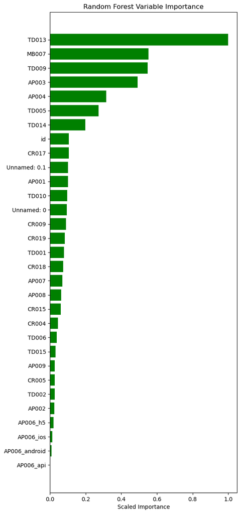

```
Top 10 Important Features:
['TD013', 'MB007', 'TD009', 'AP003', 'AP004', 'TD005', 'TD014', 'id', 'CR017', 'Unnamed: 0.1']
```

```python
# Create new Random Forest with best parameters
rf_model = H2ORandomForestEstimator(
    model_id='rf_model',
    ntrees=500,
    max_depth=40,
    min_rows=50,
    sample_rate=0.632,
    col_sample_rate_per_tree=1,
    seed=1234
)

# Train the model
rf_model.train(predictors, target, training_frame=train_hex)

importance_df=VarImp(rf_model, 'Random Forest')

# Get top 10 important features from the H2O model
top_10_features = importance_df.head(10)['variable'].tolist()
print("Top 10 Important Features:")
print(top_10_features)
```

### Section 2.2 Scikit-learn Random forest model with top 10 important features

##### Transferring the type of MB007 from objective into numerical data by encoding.

##### Becuase the loan default is the binary problem, the classification is used, which means default or not.

```python
X_train = train[top_10_features]
y_train = train['loan_default']
X_test = test[top_10_features]
y_test = test['loan_default']

var = pd.DataFrame(X_train.dtypes)
var
```

|  | 0 |
| --- | --- |
| TD013 | int64 |
| MB007 | object |
| TD009 | int64 |
| AP003 | int64 |
| AP004 | int64 |
| TD005 | int64 |
| TD014 | int64 |
| id | int64 |
| CR017 | int64 |
| Unnamed: 0.1 | int64 |

```
Found object columns to encode: ['MB007']
Encoded MB007: 49 unique values
```

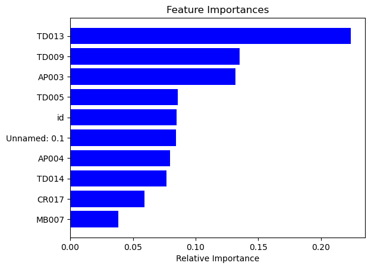

```python
def encode_all_objects(X_train, X_test):
    """
    Automatically detect and encode all object-type columns in both training and test sets
    """
    # Make copies to avoid modifying original data
    X_train_encoded = X_train.copy()
    X_test_encoded = X_test.copy()

    # Get list of object columns
    object_columns = X_train.select_dtypes(include=['object']).columns

    if len(object_columns) > 0:
        print(f"Found object columns to encode: {list(object_columns)}")

        for col in object_columns:
            # Get unique values from both train and test
            all_values = pd.concat([X_train[col], X_test[col]]).unique()

            # Create a mapping dictionary
            value_to_id = {val: idx for idx, val in enumerate(all_values)}

            # Transform both series using the mapping
            X_train_encoded[col] = X_train[col].map(value_to_id)
            X_test_encoded[col] = X_test[col].map(value_to_id)

            print(f"Encoded {col}: {len(value_to_id)} unique values")
    else:
        print("No object columns found")

    return X_train_encoded, X_test_encoded

# Use the function
X_train, X_test = encode_all_objects(X_train, X_test)

from sklearn.ensemble import RandomForestClassifier
# Initialize and train the model
sk_rf = RandomForestClassifier(
    n_estimators=500,
    max_depth=40,
    min_samples_leaf=50,
    random_state=1234
)
sk_rf.fit(X_train, y_train)

sk_rf_importances = sk_rf.feature_importances_
sk_rf_indices = np.argsort(sk_rf_importances)

features = X_train.columns
plt.title('Feature Importances')
plt.barh(range(len(sk_rf_indices)), sk_rf_importances[sk_rf_indices], color='b', align='center')
plt.yticks(range(len(sk_rf_indices)), [features[i] for i in sk_rf_indices])
plt.xlabel('Relative Importance')
plt.show()
```

### Section 2.3 SHAP

```python
pip install shap
```

```python
import shap
```

```python
shap_values = shap.TreeExplainer(sk_rf).shap_values(X_train)
```

```python
shap_values_class1 = shap_values[:, :, 1]  # Shape will be (4800, 10)
shap_values_class0 = shap_values[:, :, 0]  # Shape will be (4800, 10)
```

```python
np.shape(shap_values[0,:,1])
```

```
(10,)
```

Summary Plot

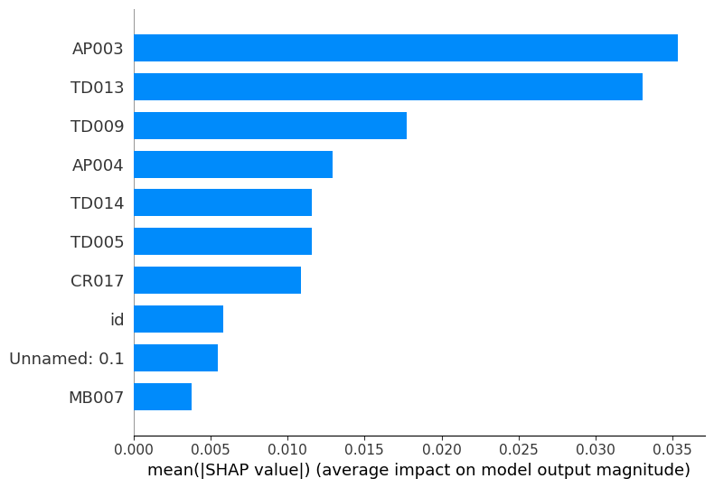

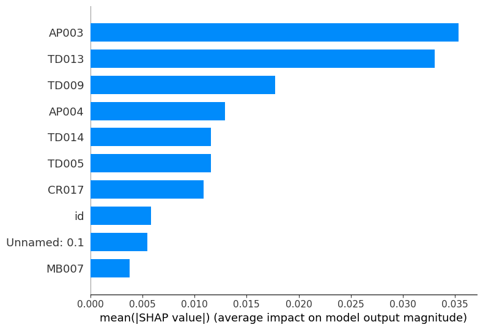

```python
shap.summary_plot(shap_values_class1, X_train, plot_type="bar")
shap.summary_plot(shap_values_class0, X_train, plot_type="bar")
```

ABS Summary Plot

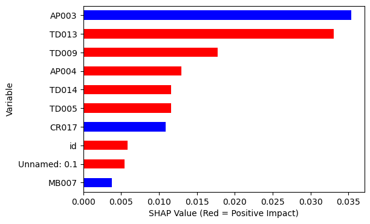

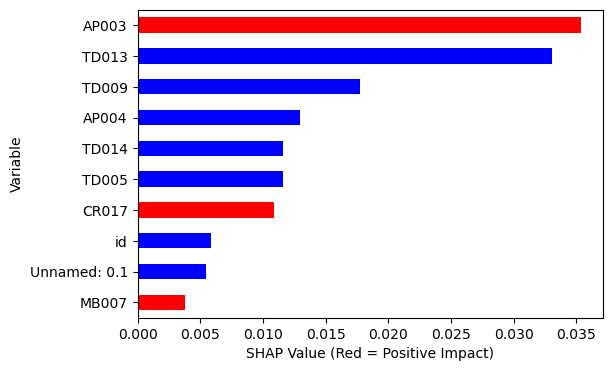

```python
def ABS_SHAP(df_shap,df):
    #import matplotlib as plt
    # Make a copy of the input data
    shap_v = pd.DataFrame(df_shap)
    feature_list = df.columns
    shap_v.columns = feature_list
    df_v = df.copy().reset_index().drop('index',axis=1)

    # Determine the correlation in order to plot with different colors
    corr_list = list()
    for i in feature_list:
        b = np.corrcoef(shap_v[i],df_v[i])[1][0]
        corr_list.append(b)
    corr_df = pd.concat([pd.Series(feature_list),pd.Series(corr_list)],axis=1).fillna(0)
    # Make a data frame. Column 1 is the feature, and Column 2 is the correlation coefficient
    corr_df.columns  = ['Variable','Corr']
    corr_df['Sign'] = np.where(corr_df['Corr']>0,'red','blue')

    # Plot it
    shap_abs = np.abs(shap_v)
    k=pd.DataFrame(shap_abs.mean()).reset_index()
    k.columns = ['Variable','SHAP_abs']
    k2 = k.merge(corr_df,left_on = 'Variable',right_on='Variable',how='inner')
    k2 = k2.sort_values(by='SHAP_abs',ascending = True)
    colorlist = k2['Sign']
    ax = k2.plot.barh(x='Variable',y='SHAP_abs',color = colorlist, figsize=(6,4),legend=False)
    ax.set_xlabel("SHAP Value (Red = Positive Impact)")

ABS_SHAP(shap_values_class1,X_train)
ABS_SHAP(shap_values_class0,X_train)
```

##### TOP 5 important features for target variable are AP003, TD013, TD009, AP004, and TD014. AP003 shows a negative relationship with target varibale default = 1, respectively, shows a positive relationship with target variable default = 0. TD013, TD009, AP004, TD014 show a positive relationship with target varaible defauly = 1, and negative relationship with target variable default = 0.

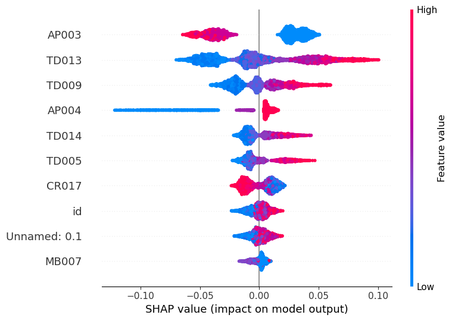

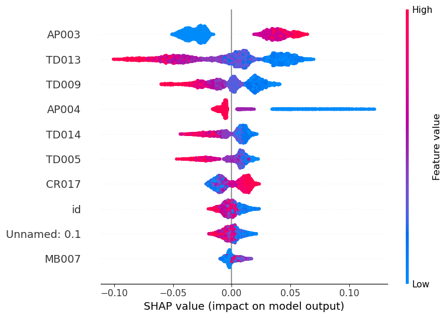

```python
shap.summary_plot(shap_values_class1, X_train)
shap.summary_plot(shap_values_class0, X_train)
```

##### Feature importance: Those Variables are ranked in descending order.

##### Impact: The horizontal location shows whether the effect of that value is associated with a higher or lower prediction.

##### Original value: Color shows whether that variable is high (in red) or low (in blue) for that observation.

##### Correlation: A high level of AP003 content has a high and negative impact on the target varibale default = 1. The “high” comes from the red color, and the negative impact is shown on the X-axis. TD013, TD009, AP004, TD014 content has a high positive impact on the target variable default = 1. The High comes from the red color, and the positive impact is shown on the X-axis.

##### All in all, the default = 1 and default = 0 are symmetric on two graphs.

The dependence_plot

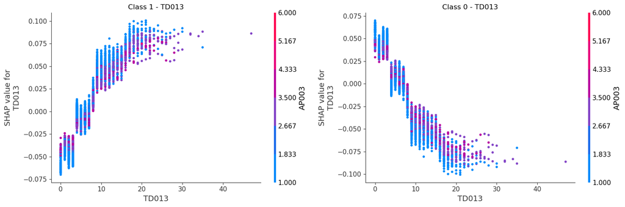

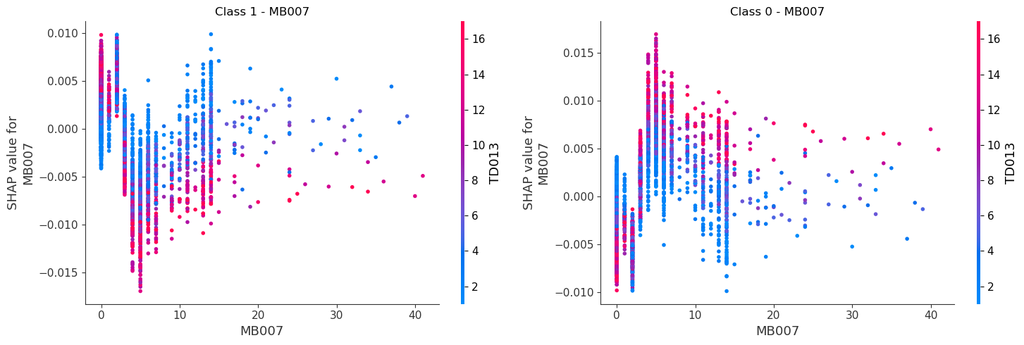

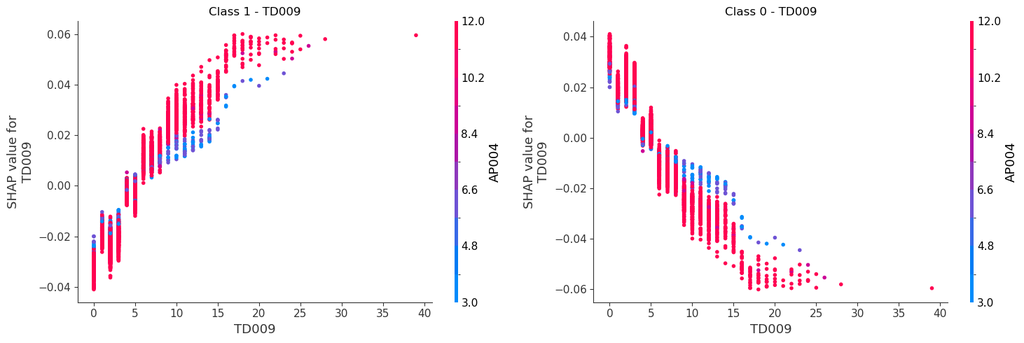

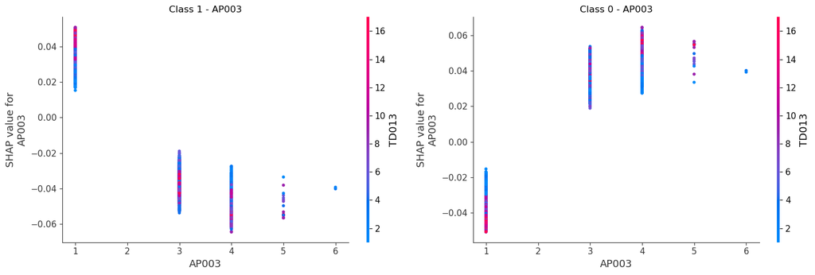

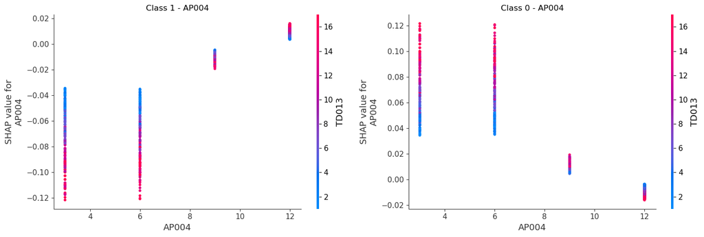

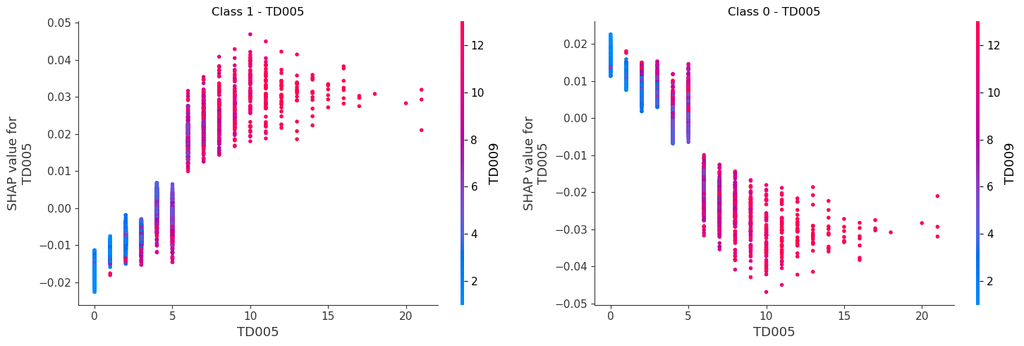

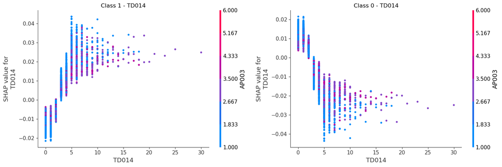

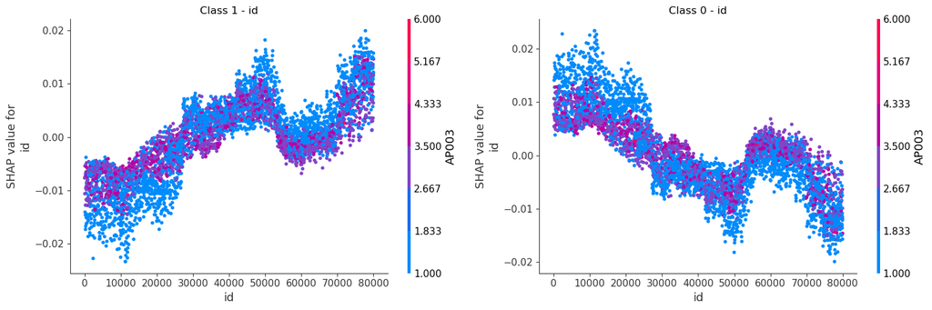

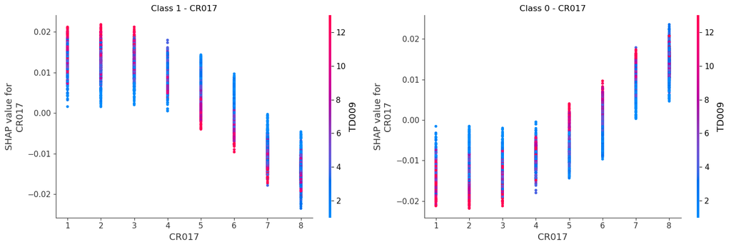

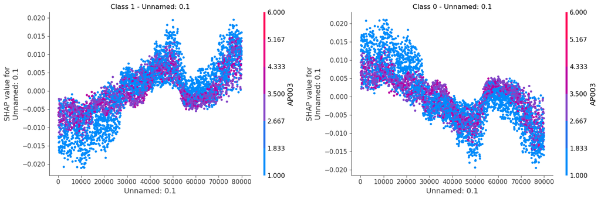

```python
for i in X_train.columns:
    # Create a figure with 1 row and 2 columns
    fig, (ax1, ax2) = plt.subplots(1, 2, figsize=(15, 5))

    # Plot class 1 on the left subplot
    plt.sca(ax1)
    shap.dependence_plot(i, shap_values_class1, X_train, ax=ax1, show=False)
    ax1.set_title(f'Class 1 - {i}')

    # Plot class 0 on the right subplot
    plt.sca(ax2)
    shap.dependence_plot(i, shap_values_class0, X_train, ax=ax2, show=False)
    ax2.set_title(f'Class 0 - {i}')

    # Adjust layout to prevent overlap
    plt.tight_layout()
    plt.show()
```